# 01 – Explore the data

- Show All Code
- Hide All Code
- View Source

Bio253 HS2026 · S. aureus JE2 proteome

**Goal:** get to know the data *before* testing anything. After this notebook you should be able to answer: How many proteins? How many samples? Do the replicates look alike? Which factor (genotype or medium) changes the proteome most? How much is missing?

```r
source("../R/setup.R")
```

## 1. Load the data

```r
samples    <- read_samples()
abundances <- read_abundances("total")   # long: one row per protein x sample
dea        <- read_dea("total")          # long: one row per protein x contrast

samples
```

| sample | genotype | medium | replicate | group | raw_file_total | sample_name_in_excel |
| --- | --- | --- | --- | --- | --- | --- |
| JE2anc_TSB_1 | anc | TSB | 1 | anc_TSB | 20260612_003_C41881_S1143451_JE2anc_TSB_1_input | JE2anc_TSB_1 |
| JE2anc_TSB_2 | anc | TSB | 2 | anc_TSB | 20260612_004_C41881_S1143452_JE2anc_TSB_2_input | JE2anc_TSB_2 |
| JE2anc_TSB_3 | anc | TSB | 3 | anc_TSB | 20260612_005_C41881_S1143453_JE2anc_TSB_3_input | JE2anc_TSB_3 |
| JE2anc_pulseSN_1 | anc | SNpulse | 1 | anc_SNpulse | 20260612_009_C41881_S1143457_JE2anc_pulseSN_1_input | 2anc_pulseSN_1 |
| JE2anc_pulseSN_2 | anc | SNpulse | 2 | anc_SNpulse | 20260612_010_C41881_S1143458_JE2anc_pulseSN_2_input | 2anc_pulseSN_2 |
| JE2anc_pulseSN_3 | anc | SNpulse | 3 | anc_SNpulse | 20260612_011_C41881_S1143459_JE2anc_pulseSN_3_input | 2anc_pulseSN_3 |
| JE2anc_SN_1 | anc | SN | 1 | anc_SN | 20260612_006_C41881_S1143454_JE2anc_SN_1_input | JE2anc_SN_1 |
| JE2anc_SN_2 | anc | SN | 2 | anc_SN | 20260612_007_C41881_S1143455_JE2anc_SN_2_input | JE2anc_SN_2 |
| JE2anc_SN_3 | anc | SN | 3 | anc_SN | 20260612_008_C41881_S1143456_JE2anc_SN_3_input | JE2anc_SN_3 |
| JE2stk_TSB_1 | stk | TSB | 1 | stk_TSB | 20260612_012_C41881_S1143460_JE2stk_TSB_1_input | JE2stk_TSB_1 |
| JE2stk_TSB_2 | stk | TSB | 2 | stk_TSB | 20260612_013_C41881_S1143461_JE2stk_TSB_2_input | JE2stk_TSB_2 |
| JE2stk_TSB_3 | stk | TSB | 3 | stk_TSB | 20260612_014_C41881_S1143462_JE2stk_TSB_3_input | JE2stk_TSB_3 |
| JE2stk_pulseSN_1 | stk | SNpulse | 1 | stk_SNpulse | 20260612_019_C41881_S1143466_JE2stk_pulseSN_1_input | 2stk_pulseSN_1 |
| JE2stk_pulseSN_2 | stk | SNpulse | 2 | stk_SNpulse | 20260612_020_C41881_S1143467_JE2stk_pulseSN_2_input | 2stk_pulseSN_2 |
| JE2stk_pulseSN_3 | stk | SNpulse | 3 | stk_SNpulse | 20260612_021_C41881_S1143468_JE2stk_pulseSN_3_input | 2stk_pulseSN_3 |
| JE2stk_SN_1 | stk | SN | 1 | stk_SN | 20260612_016_C41881_S1143463_JE2stk_SN_1_input | JE2stk_SN_1 |
| JE2stk_SN_2 | stk | SN | 2 | stk_SN | 20260612_017_C41881_S1143464_JE2stk_SN_2_input | JE2stk_SN_2 |
| JE2stk_SN_3 | stk | SN | 3 | stk_SN | 20260612_018_C41881_S1143465_JE2stk_SN_3_input | JE2stk_SN_3 |
| JE2stp_TSB_1 | stp | TSB | 1 | stp_TSB | 20260612_022_C41881_S1143469_JE2stp_TSB_1_input | JE2stp_TSB_1 |
| JE2stp_TSB_2 | stp | TSB | 2 | stp_TSB | 20260612_023_C41881_S1143470_JE2stp_TSB_2_input | JE2stp_TSB_2 |
| JE2stp_TSB_3 | stp | TSB | 3 | stp_TSB | 20260612_024_C41881_S1143471_JE2stp_TSB_3_input | JE2stp_TSB_3 |
| JE2stp_pulseSN_1 | stp | SNpulse | 1 | stp_SNpulse | 20260612_029_C41881_S1143475_JE2stp_pulseSN_1_input | 2stp_pulseSN_1 |
| JE2stp_pulseSN_2 | stp | SNpulse | 2 | stp_SNpulse | 20260612_030_C41881_S1143476_JE2stp_pulseSN_2_input | 2stp_pulseSN_2 |
| JE2stp_pulseSN_3 | stp | SNpulse | 3 | stp_SNpulse | 20260612_031_C41881_S1143477_JE2stp_pulseSN_3_input | 2stp_pulseSN_3 |
| JE2stp_SN_1 | stp | SN | 1 | stp_SN | 20260612_025_C41881_S1143472_JE2stp_SN_1_input | JE2stp_SN_1 |
| JE2stp_SN_2 | stp | SN | 2 | stp_SN | 20260612_026_C41881_S1143473_JE2stp_SN_2_input | JE2stp_SN_2 |
| JE2stp_SN_3 | stp | SN | 3 | stp_SN | 20260612_027_C41881_S1143474_JE2stp_SN_3_input | JE2stp_SN_3 |

```r
tibble(
  what  = c("samples", "proteins (no contaminants)", "contrasts", "rows in abundance table"),
  value = c(n_distinct(abundances$sample), n_distinct(abundances$protein_key),
            n_distinct(dea$contrast), nrow(abundances))
)
```

| what | value |
| --- | --- |
| samples | 27 |
| proteins (no contaminants) | 2324 |
| contrasts | 33 |
| rows in abundance table | 62748 |

**TipLong vs wide**

All tables are *long*: one measurement per row. That is what `dplyr` and `ggplot2` like. If you need a matrix (proteins × samples), use `pivot_wider()` – see the PCA below.

## 2. Distribution of abundances per sample

The values are already log2-transformed and normalised (vsn). Normalisation should make the sample distributions look similar.

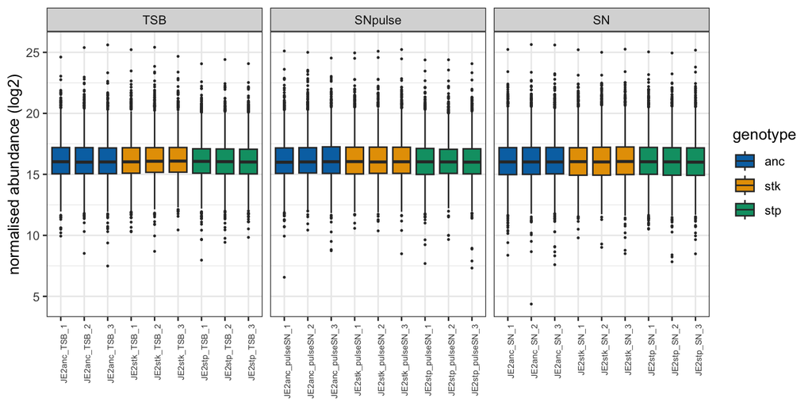

```r
ggplot(abundances, aes(sample, normalized_abundance, fill = genotype)) +
  geom_boxplot(outlier.size = 0.3, na.rm = TRUE) +
  facet_grid(~medium, scales = "free_x") +
  scale_fill_manual(values = GENOTYPE_COLOURS) +
  theme(axis.text.x = element_text(angle = 90, hjust = 1, size = 6)) +
  labs(y = "normalised abundance (log2)", x = NULL)
```

## 3. Missing values

A protein that is not detected in a sample has `NA` (not 0!). Missing values are usually **not random**: low-abundant proteins go missing more often.

```r
missing_per_sample <- abundances |>
  group_by(sample, group) |>
  summarise(n_detected = sum(!is.na(normalized_abundance)),
            n_missing  = sum(is.na(normalized_abundance)), .groups = "drop")

missing_per_sample |>
  group_by(group) |>
  summarise(mean_detected = round(mean(n_detected)), mean_missing = round(mean(n_missing)))
```

| group | mean_detected | mean_missing |
| --- | --- | --- |
| anc_TSB | 2174 | 150 |
| anc_SNpulse | 2156 | 168 |
| anc_SN | 2101 | 223 |
| stk_TSB | 2086 | 238 |
| stk_SNpulse | 2135 | 189 |
| stk_SN | 2082 | 242 |
| stp_TSB | 2183 | 141 |
| stp_SNpulse | 2197 | 127 |
| stp_SN | 2105 | 219 |

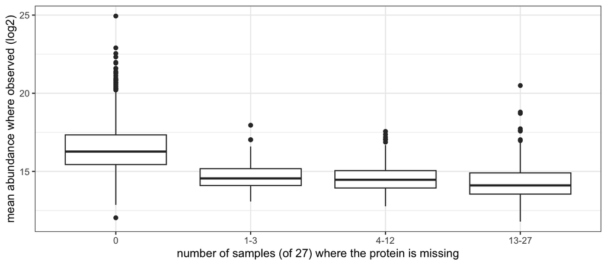

```r
# Are proteins with missing values the low-abundant ones?
abundances |>
  group_by(protein_key) |>
  summarise(mean_abundance = mean(normalized_abundance, na.rm = TRUE),
            n_missing = sum(is.na(normalized_abundance))) |>
  mutate(missing_class = cut(n_missing, c(-1, 0, 3, 12, 27),
                             labels = c("0", "1-3", "4-12", "13-27"))) |>
  ggplot(aes(missing_class, mean_abundance)) +
  geom_boxplot(na.rm = TRUE) +
  labs(x = "number of samples (of 27) where the protein is missing",
       y = "mean abundance where observed (log2)")
```

## 4. Do replicates cluster? (PCA)

PCA needs a complete matrix, so we use only proteins observed in **all** 27 samples.

```r
mat <- abundances |>
  select(protein_key, sample, normalized_abundance) |>
  pivot_wider(names_from = sample, values_from = normalized_abundance) |>
  tidyr::drop_na()
m <- as.matrix(mat[, -1])
nrow(m)   # proteins used
```

```
[1] 1765
```

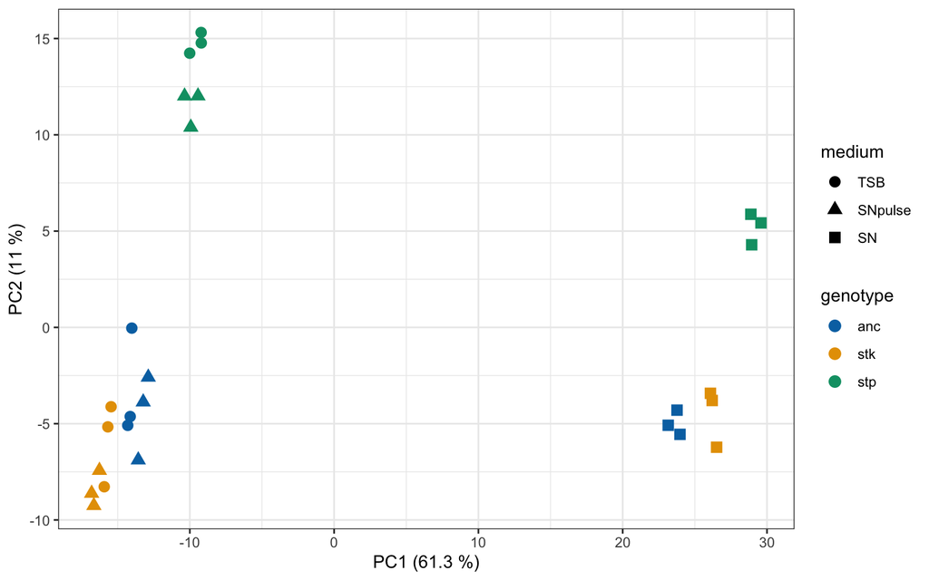

```r
pca <- prcomp(t(m), center = TRUE, scale. = FALSE)
var_explained <- round(100 * pca$sdev^2 / sum(pca$sdev^2), 1)

scores <- as_tibble(pca$x[, 1:3], rownames = "sample") |>
  left_join(samples, by = "sample")

ggplot(scores, aes(PC1, PC2, colour = genotype, shape = medium)) +
  geom_point(size = 3) +
  scale_colour_manual(values = GENOTYPE_COLOURS) +
  labs(x = paste0("PC1 (", var_explained[1], " %)"),
       y = paste0("PC2 (", var_explained[2], " %)"))
```

**Question:** Which factor separates the samples along PC1? Which along PC2? Where do the SNpulse samples sit relative to TSB and SN – and does that make sense biologically for a 15-minute exposure?

## 5. Sample–sample correlation

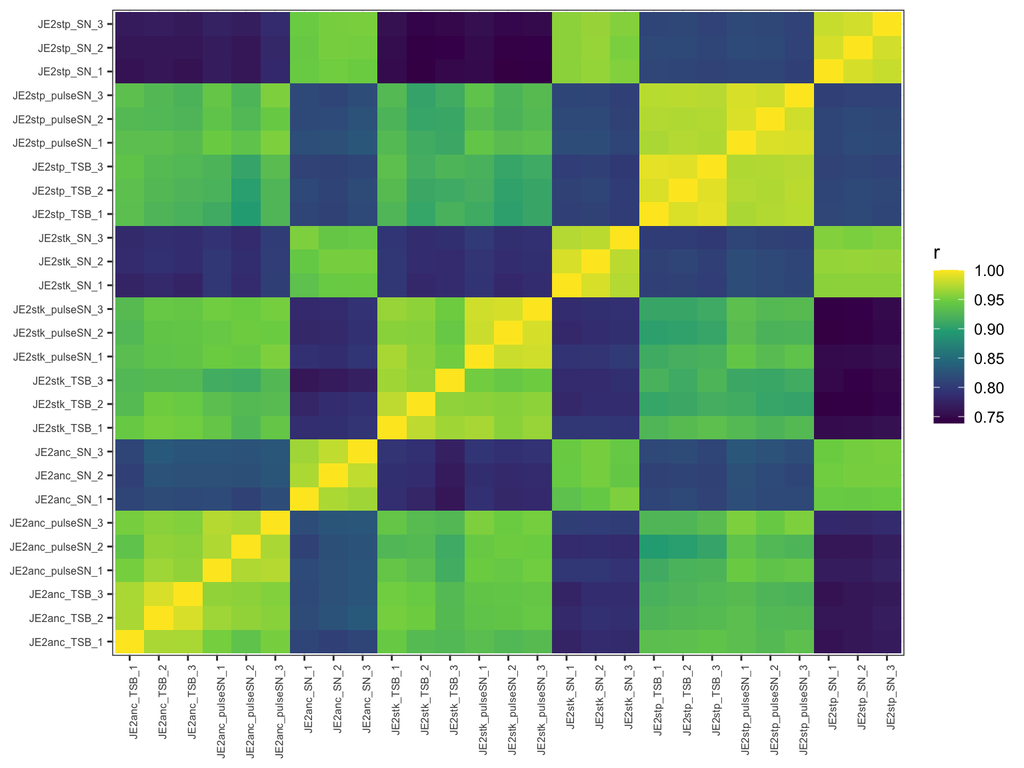

```r
cor_mat <- cor(m, method = "pearson")
order <- samples$sample   # design order: genotype, then medium
as_tibble(cor_mat, rownames = "sample_a") |>
  pivot_longer(-sample_a, names_to = "sample_b", values_to = "r") |>
  mutate(sample_a = factor(sample_a, order), sample_b = factor(sample_b, order)) |>
  ggplot(aes(sample_a, sample_b, fill = r)) +
  geom_tile() +
  scale_fill_viridis_c() +
  theme(axis.text.x = element_text(angle = 90, hjust = 1, size = 6),
        axis.text.y = element_text(size = 6)) +
  labs(x = NULL, y = NULL)
```

## 6. How many proteins change per contrast?

The DEA (prolfquapp) tested **33 contrasts**. Remember the sign rule:

```r
explain_contrast("TSB_vs_SN_at_anc")
```

```
[1] "TSB_vs_SN_at_anc: diff = log2(TSB) - log2(SN), within anc. diff > 0 means HIGHER in TSB; diff < 0 means HIGHER in SN."
```

```r
explain_contrast("interaction_stk_vs_anc_at_TSB_vs_SN")
```

```
[1] "interaction_stk_vs_anc_at_TSB_vs_SN: difference of differences = (stk - anc in TSB) - (stk - anc in SN). Positive: the stk-vs-anc difference is larger in TSB than in SN."
```

```r
hits <- count_hits(dea, fdr_cutoff = 0.1, lfc_cutoff = 1)
hits |> arrange(desc(n_hits))
```

| contrast | n_tested | n_up | n_down | n_hits |
| --- | --- | --- | --- | --- |
| SNpulse_vs_SN_at_stk | 2300 | 351 | 169 | 520 |
| TSB_vs_SN_at_stk | 2300 | 317 | 178 | 495 |
| TSB_vs_SN_at_stp | 2300 | 287 | 178 | 465 |
| TSB_vs_SN_at_anc | 2300 | 284 | 175 | 459 |
| SNpulse_vs_SN_at_stp | 2300 | 295 | 156 | 451 |
| SNpulse_vs_SN_at_anc | 2300 | 289 | 154 | 443 |
| TSB_vs_SN | 2300 | 287 | 154 | 441 |
| SNpulse_vs_SN | 2300 | 303 | 137 | 440 |
| stp_vs_stk_at_TSB | 2300 | 72 | 145 | 217 |
| stp_vs_stk_at_SNpulse | 2300 | 57 | 146 | 203 |
| stp_vs_anc_at_TSB | 2300 | 40 | 136 | 176 |
| stk_vs_anc_at_SN | 2300 | 60 | 107 | 167 |
| stp_vs_anc_at_SN | 2300 | 41 | 112 | 153 |
| interaction_stk_vs_anc_at_SNpulse_vs_SN | 2300 | 112 | 40 | 152 |
| stk_vs_anc_at_TSB | 2300 | 60 | 87 | 147 |
| stp_vs_stk | 2300 | 38 | 101 | 139 |
| stk_vs_anc_at_SNpulse | 2300 | 66 | 71 | 137 |
| interaction_stp_vs_stk_at_SNpulse_vs_SN | 2300 | 39 | 92 | 131 |
| interaction_stp_vs_stk_at_TSB_vs_SN | 2300 | 42 | 86 | 128 |
| stp_vs_anc_at_SNpulse | 2300 | 31 | 95 | 126 |
| stp_vs_stk_at_SN | 2300 | 42 | 73 | 115 |
| interaction_stk_vs_anc_at_TSB_vs_SN | 2300 | 64 | 37 | 101 |
| interaction_stp_vs_anc_at_TSB_vs_SN | 2300 | 45 | 55 | 100 |
| interaction_stp_vs_anc_at_SNpulse_vs_SN | 2300 | 53 | 46 | 99 |
| stp_vs_anc | 2300 | 19 | 74 | 93 |
| stk_vs_anc | 2300 | 39 | 52 | 91 |
| TSB_vs_SNpulse_at_stk | 2300 | 15 | 71 | 86 |
| TSB_vs_SNpulse | 2300 | 14 | 43 | 57 |
| TSB_vs_SNpulse_at_anc | 2300 | 20 | 37 | 57 |
| interaction_stk_vs_anc_at_TSB_vs_SNpulse | 2300 | 9 | 36 | 45 |
| TSB_vs_SNpulse_at_stp | 2300 | 8 | 34 | 42 |
| interaction_stp_vs_stk_at_TSB_vs_SNpulse | 2300 | 9 | 9 | 18 |
| interaction_stp_vs_anc_at_TSB_vs_SNpulse | 2300 | 4 | 6 | 10 |

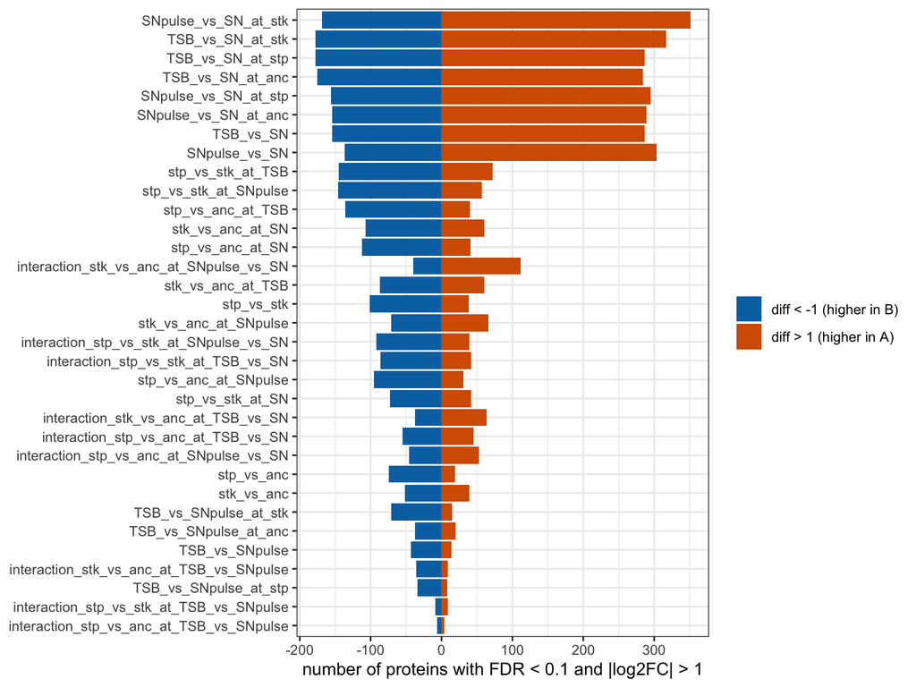

```r
hits |>
  pivot_longer(c(n_up, n_down), names_to = "direction", values_to = "n") |>
  mutate(n = if_else(direction == "n_down", -n, n),
         contrast = reorder(contrast, n_hits)) |>
  ggplot(aes(n, contrast, fill = direction)) +
  geom_col() +
  scale_fill_manual(values = c(n_up = "#D55E00", n_down = "#0072B2"),
                    labels = c(n_up = "diff > 1 (higher in A)", n_down = "diff < -1 (higher in B)")) +
  labs(x = "number of proteins with FDR < 0.1 and |log2FC| > 1", y = NULL, fill = NULL)
```

How much of this rests on imputed group means?

```r
dea |>
  filter(FDR < 0.1, abs(diff) > 1) |>
  count(contrast, estimate_type) |>
  pivot_wider(names_from = estimate_type, values_from = n, values_fill = 0) |>
  arrange(desc(observed))
```

| contrast | lod_imputed | observed |
| --- | --- | --- |
| SNpulse_vs_SN_at_stk | 53 | 467 |
| TSB_vs_SN_at_stk | 45 | 450 |
| TSB_vs_SN_at_stp | 44 | 421 |
| SNpulse_vs_SN_at_stp | 43 | 408 |
| TSB_vs_SN_at_anc | 53 | 406 |
| SNpulse_vs_SN | 35 | 405 |
| TSB_vs_SN | 39 | 402 |
| SNpulse_vs_SN_at_anc | 55 | 388 |
| stp_vs_stk_at_TSB | 27 | 190 |
| stp_vs_stk_at_SNpulse | 33 | 170 |
| stp_vs_anc_at_TSB | 25 | 151 |
| stk_vs_anc_at_SN | 26 | 141 |
| interaction_stk_vs_anc_at_SNpulse_vs_SN | 26 | 126 |
| stp_vs_stk | 14 | 125 |
| stp_vs_anc_at_SN | 29 | 124 |
| stk_vs_anc_at_TSB | 26 | 121 |
| interaction_stp_vs_stk_at_SNpulse_vs_SN | 18 | 113 |
| stk_vs_anc_at_SNpulse | 25 | 112 |
| interaction_stp_vs_stk_at_TSB_vs_SN | 21 | 107 |
| stp_vs_anc_at_SNpulse | 27 | 99 |
| stp_vs_stk_at_SN | 17 | 98 |
| interaction_stk_vs_anc_at_TSB_vs_SN | 12 | 89 |
| interaction_stp_vs_anc_at_TSB_vs_SN | 13 | 87 |
| stp_vs_anc | 8 | 85 |
| interaction_stp_vs_anc_at_SNpulse_vs_SN | 17 | 82 |
| stk_vs_anc | 12 | 79 |
| TSB_vs_SNpulse_at_stk | 17 | 69 |
| TSB_vs_SNpulse | 12 | 45 |
| TSB_vs_SNpulse_at_anc | 14 | 43 |
| interaction_stk_vs_anc_at_TSB_vs_SNpulse | 7 | 38 |
| TSB_vs_SNpulse_at_stp | 9 | 33 |
| interaction_stp_vs_stk_at_TSB_vs_SNpulse | 5 | 13 |
| interaction_stp_vs_anc_at_TSB_vs_SNpulse | 3 | 7 |

**Warning`lod_imputed`**

`estimate_type == "lod_imputed"` means at least one group mean was **not measured** but estimated from the limit of detection. Such fold changes can be large and “significant” just because a protein was not seen in one group. Treat them as *present/absent* evidence and always look at the per-sample plot.

## 7. A first volcano plot

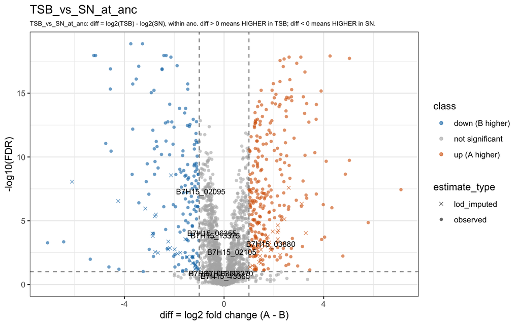

```r
volcano(dea, "TSB_vs_SN_at_anc", highlight = KEY_PROTEINS$locus_tag)
```

## Your notes

- What surprised you?
- Which contrast would you like to look at in more detail – and why?
- Write it down in `notebook/` (see `notebook/README.md`).